# Projet R M1 MAS

NGUYEN_PHAM_BEYE_DHENNIN

13/11/2021

Dans un soucis de lisibilité, nous avons préféré laisser dans les chuncks nos commentaires sauf pour le dernier exercice de notre Partie 2.

# Projet : Partie 1

## Greatest Albums

### 1. Représenter graphiquement le nombre d’albums inclus dans le top par année. Commenter les résultats.

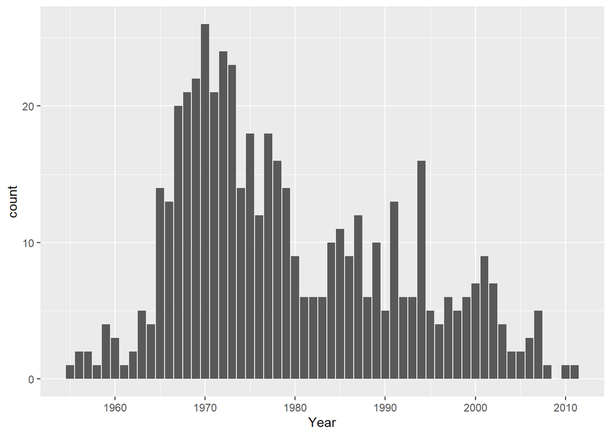

```r
top500 <- read.csv("albums.csv", header=TRUE, stringsAsFactors=FALSE  )
ggplot(top500, aes(Year)) + geom_bar()
```

### 2. Afficher le nom et le nombre d’albums pour les artistes ayant au moins 5 albums dans le top. L’affichage se fera par ordre décroissant de nombre d’albums.

```r
top500 %>%
  count(Artist) %>%
  filter(n>=5) %>%
  arrange(desc(n))
```

```
##                Artist  n
## 1           Bob Dylan 10
## 2         The Beatles 10
## 3  The Rolling Stones 10
## 4   Bruce Springsteen  8
## 5             The Who  7
## 6         David Bowie  5
## 7          Elton John  5
## 8        Led Zeppelin  5
## 9           Radiohead  5
## 10                 U2  5
## 11    Various Artists  5
```

### 3. Quel est le genre le plus représenté dans le Top 500 de Rolling Stones?

```r
top500 %>%
  count(Genre) %>%
  arrange(desc(n)) %>%
  head(1)
```

```
##   Genre   n
## 1  Rock 249
```

```r
## Le genre le plus représenté dans le Top 500 de Rolling Stones est le Rock, en apparaissant 249 fois.
```

## Chansons

### Importer le fichier dans un tableau nommé tracks.

```r
tracks <- read.csv("tracks.csv", header=TRUE, stringsAsFactors=FALSE  )
```

### 1. Faire un top des 1000 chansons les plus dansables (variable danceability). En cas d’égalité, départager les chansons en fonction de leur popularité.

```r
top_1000_dansable <- tracks %>%
  arrange(desc(danceability),Popularity) %>%
  distinct(Track.Name,.keep_all = TRUE) %>%
  head(1000)
#View(top_1000_dansable)
```

#### • Quels sont les 9 artistes les plus représentés ?

```r
top_1000_dansable %>%
  count(Artist.Name) %>%
  arrange(desc(n)) %>%
  head(9)
```

```
##            Artist.Name n
## 1         Hadag Nahash 8
## 2       Britney Spears 7
## 3           Gucci Mane 6
## 4  Megan Thee Stallion 6
## 5         Moneybagg Yo 6
## 6             Saweetie 6
## 7                Peled 5
## 8    Young Stoner Life 5
## 9 A Tribe Called Quest 4
```

#### • Et la classe (variable Class) la plus représentée ? Illustrer la répartition des classes dans ce top.

```r
top_1000_dansable %>%
  count(Class) %>%
  arrange(desc(n)) %>%
  head(1)
```

```
##   Class   n
## 1     5 473
```

```r
## La classe la plus représentée est la classe 5, en apparaissant 473 fois.
```

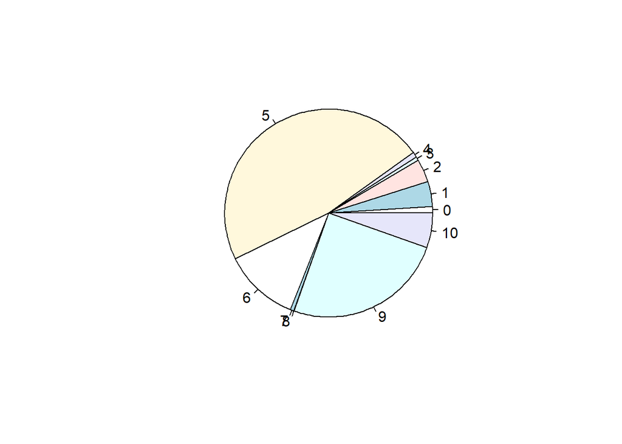

```r
pie((top_1000_dansable%>%count(Class))$n,labels = (top_1000_dansable%>%count(Class))$Class)
```

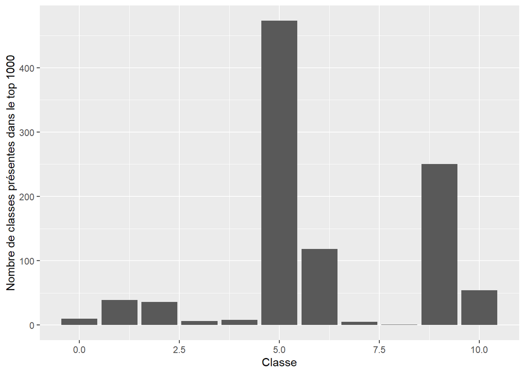

```r
top_1000_dansable %>% ggplot() + aes(x = Class) + geom_bar() + xlab("Classe") + ylab("Nombre de classes présentes dans le top 1000")
```

```r
## Nous avons choisi d'illustrer la répartition des classes dans ce top de deux manières différentes.
## En effet, pie chart est très visuel avec ses couleurs et permet d'avoir toutes les valeurs. Quant à l'histogramme, le fait de pouvoir choisir le nom des axes permet de rendre ce graphique aussi très compréhensible.

## On remarque qu'il y a une grande présence de classe 5 et 9.
```